# L11

# Reinforcement Learning Contd.

## Passive RL

- How to learn from already given experiences
- Given:
  - Set of states $s\in{S}$
  - Set of actions (per state) $A$
- Looking for $\pi(s)$
- Don’t know
  - A model $T(s,a,s')$
  - A reward function $R(s,a,s')$
- Big idea ≙ compute all averages over $T$ using sample outcomes

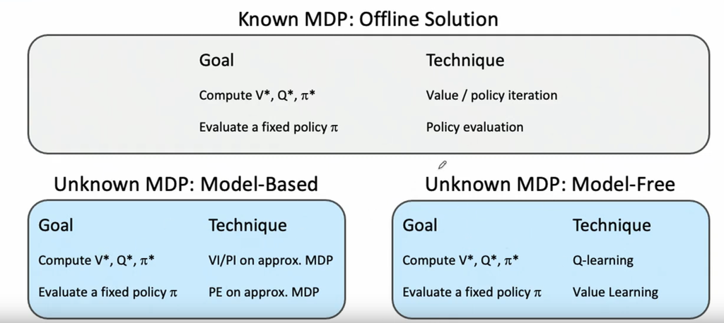

### Model-Free Learning

- Temporal difference learning
- Receives stream of experiences from the world eg: $(s,a,r,s',a',r',s'',{\dots})$
- Update estimates each transition
- Over time, updates will mimic Bellman updates
- Q-iteration: do Q-value updates to each Q-state:
  $$Q_{k+1}(s,a)=\sum_{s'}T(s,a,s')[R(s,a,s')+{\gamma}\max_{a'}Q_{k}(s',a')]$$
  - $Q_{0}(s,a)=0$
  - Can’t compute this update without $T$ and $R$
- Q-learning: instead, compute average as we go
  - Receive a sample transition $(s,a,r,s')$
  - Use initial approximation $Q(s,a)\approx{r+{\gamma}\max_{a'}Q(s',a')}$ to compute:
    $$Q(s,a)=(1-{\alpha})Q(s,a)+{\alpha}[r+{\gamma}\max_{a'}Q(s',a')]$$
  - $\pi^{*}(s)=\arg\max_{a}(Q(s,a))$
  - AKA off-policy learning
  - Have to explore enough to be good
  - Have to eventually make the learning rate small enough (but not decrease it too quickly)
  - Type of active RL

## Active RL

- Need to consider exploration vs exploitation

### Choosing How to Explore

- Simplest: random actions (${\varepsilon}$-greedy)
  - Every time step, flip a coin
  - With (small) probability ${\varepsilon}$, act randomly
  - With (large) probability $1-{\varepsilon}$, act on current policy
  - ${\varepsilon}$ high during early learning stage and low at end
- Better idea: explore areas whose badness is not (yet) established; eventually stop exploring
  - Use an exploration function that takes a value estimate $u$ and a visit count $n$ and returns an optimistic utility, eg: $f(u,n)=u+\frac{k}{n}\vert_{k\;\hat{=}\;{\text{preset constant}}}$
  - Then use
    $$Q(s,a)\leftarrow_{{\alpha}}{\alpha}R(s,a,s')+{\gamma}\max_{a'}f(Q(s',a'),N(s',a'))$$
    - Note: $x\leftarrow_{{\alpha}}\implies{x\leftarrow(1-{\alpha})x+{\alpha}v}$

### Regret

- Even if you learn the optimal policy, you still make mistakes along the way
- Regret ≙ a measure of total mistake cost
  - Difference between your (expected) rewards, including youthful suboptimality, and optimal (expected) rewards
- eg: random exploration and exploration functions both end up optimal, but random exploration has higher regret

## Dealing with Large State Spaces

- Use approximate Q-learning
- Basic Q-Learning keeps a table of all q-values
  - This is not possible in reality; too much state
- Idea: Learn about some small number of training states from experience
  - Generalize that experience to new, similar situations
- Solution: linear value functions: describe state using a vector of features (properties) $(f_{1},f_{2},f_{3},{\dots},f_{n})$
  - Features are functions from states to real numbers (often 0/1) that capture important properties of the state
    - eg: distance to closest ghost, is pacman in a tunnel, etc.
    - Can also describe a q-state $(s,a)$ with features
- Using a feature representation, we can write a Q-function (or value function) for any state using a few weights $(w_{1},w_{2},{\dots},w_{n})$:
  $$\begin{array}{c}
  V(s)=w_{1}f_{1}(s)+w_{2}f_{2}(s)+{\dots}+w_{n}f_{n}(s) \\
  Q(s,a)=w_{1}f_{1}(s,a)+w_{2}f_{2}(s,a)+{\dots}+w_{n}f_{n}(s,a)
  \end{array}$$
  - Advantage: our experience is summed up in a few powerful numbers $\{w_{1},w_{2},{\dots},w_{n}\}$
  - Disadvantage: states may share features but actually be very different in value
- Q-learning with linear Q-functions:
  $$\begin{array}{l}
  \mathrm{transition}=(s,a,r,s') \\
  \mathrm{difference}=[r+{\gamma}\max_{a'}Q(s',a')]-Q(s,a) \\
  Q(s,a)\leftarrow{Q(s,a)+{\alpha}[\mathrm{difference}]} \\
  w_{i}\leftarrow{w_{i}+{\alpha}[\mathrm{difference}]f_{i}(s,a)}
  \end{array}$$